In addition to assisting researchers with their research, we also develop tools to assist with various tasks (primarily statistical and reporting). In the spirit of open science, we share these tools on various sharing platforms.

## R packages

R is one of the two main statistical programming languages used at CTU Bern. During our work, we have developed the following packages for various tasks.

### [`accrualPlot`](https://github.com/CTU-Bern/accrualPlot)

[figure not shown]

With `accrualPlot`, it is easy to depict recruitment as a cumulative incidence curve, a bar plot or to estimate the time point at which a given number of participants will be been enrolled.

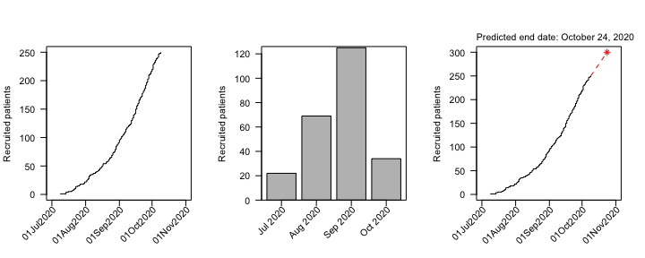

More information on `accrualPlot` is available [here](https://ctu-bern.github.io/accrualPlot).

### [`btabler`](https://github.com/CTU-Bern/btabler)

[figure not shown]

`btabler` is a wrapper around the [`xtable`](https://cran.r-project.org/web/packages/xtable/) package allowing more optimized tables for use in LaTeX reports.

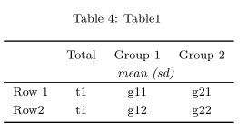

More information on `btabler` is available [here](https://ctu-bern.github.io/btabler/).

### [`HSAr`](https://github.com/CTU-Bern/HSAr)

`HSAr` is a by-product of CTU Bern’s involvement in the SNFs [Smarter Health Case National Research Programme (NRP74)](http://www.nfp74.ch). It provides an approach for creating so-called Hospital Service Areas - aggregated areas supposed to reflect the patterns of flow from people live to where they go to hospital. The method is described [here](https://onlinelibrary.wiley.com/doi/full/10.1111/1475-6773.13275). (The main repository is [here](https://github.com/aghaynes/HSAr))

Note: `HSAr` was written using packages which have since been deprecated. This makes using the package more difficult (if at all possible). The future of the package is under consideration.

### [`kpitools`](https://github.com/CTU-Bern/kpitools)

[figure not shown]

Risk based monitoring was introduced as a GCP topic in the ICH GCP E6(R2) revision with the aim of identifying particularly important risks to a trial in order to circumvent them earlier and limit their influence on a given trial. `kpitools` has tools to assist in the calculation and reporting of such risks (i.e. Key Performance Indicators, KPIs).

More information on `kpitools` is available [here](https://ctu-bern.github.io/kpitools).

### [`presize`](https://github.com/CTU-Bern/presize)

[figure not shown]

`presize` is a package for precision based sample size calculations. Rather than having a specific hypothesis to test, a trial might be rather aimed at estimating the magnitude of an effect and want to have an estimate with a certain precision (e.g. ‘how wide would my confidence interval be with so-and-so many participants?’, or ‘how many participants would be required to attain a confidence interval so wide?’).

`presize` is available on [CRAN](https://cran.r-project.org/web/packages/presize) and a user-friendly, non-programmatic version of the application is available [here](https://shiny.ctu.unibe.ch/presize/) for those unfamiliar with R.

### [`redcaptools`](https://github.com/CTU-Bern/redcaptools)

`redcaptools` provides tools to support working with REDCap datasets. It contains functions for exporting data through the REDCap Application Programming Interface, functions for preparing data for downstream use (e.g. adding labels, converting strings to dates). It also provides methods to export data in a form based manner (i.e. each instrument is a separate data frame) and to split a standard export into forms.

More information on `redcaptools` is available [here](https://ctu-bern.github.io/redcaptools).

[figure not shown]

Annual Safety Reports (ASR) are an important part of the reporting obligations for Clinical Trials. They are also time consuming to prepare. `SwissASR` provides a simple way to fill out the ASR in an automated manner. Prepare the data in the manner expected by `SwissASR`, and you can easily rerun the code the next year, with minimal modification.

Visit the [`SwissASR` package website](https://ctu-bern.github.io/SwissASR) or [Swiss Clinical Trial Organizations Statistics and Methodology Platform website](https://swissclinicaltrialorganisation.github.io/stats_platform/safetyreporting.html) for more information.

### Shiny server

Shiny is an extension to the R language for creating interactive web applications. For example, such applications could be used to display results, perform calculations, or provide simple data exploration capabilities. CTU Bern has it’s own shiny server where we can host such applications.

We currently host the following applications:

- [`covid19sm`](https://covid19.ctu.unibe.ch/) Aims to offer monthly monitoring of the impact of the COVID-19 pandemic on the life and health of the Swiss population.
- [`presize`](https://shiny.ctu.unibe.ch/presize/) is the companion app to the `presize` R package detailed above. It provides methods for precision based sample size calculation.
- The SCTO Monitoring platform developed a Risk Based Monitoring Score Calculator for determining the appropriate degree of monitoring for a trial. CTU bern and the SCTO Statistics and Methodology converted this to a simple to use [Shiny application](https://shiny.ctu.unibe.ch/app/rbmsc/). See the [SCTO site](https://www.sctoplatforms.ch/en/tools/risk-based-monitoring-score-calculator-31.html) for more information.

If you have an idea for an application, get in touch via the [consulting form](https://www.ctu.unibe.ch/about_us/contact/forms/contact_us___statistics/index_eng.html) and we would be happy discuss possibilities.

### R Package universe

[figure not shown]

CTU Bern also has a so-called [universe](https://ctu-bern.r-universe.dev), hosted by [ROpenSci](https://ropensci.org/r-universe/), for easier installation of our R packages. For packages not on CRAN, and those with versions not yet posted to CRAN, it allows the installation of packages as if the packages in the universe were a part of CRAN. For instance, `presize` is on [CRAN](https://cran.r-project.org/web/packages/presize) but it’s development version is on [GitHub](https://github.com/CTU-Bern/presize). The CRAN version of the package can be installed with `install.packages("presize")`, while the development version must be installed with `remotes::install_github("CTU-Bern/presize")`. By using the CTU-Bern universe, it is possible to install the development version of `presize` via the first syntax. The following code can be used to tell R to search the CTU Bern universe for a package first and install it from there if available and if not search CRAN instead (or whatever repository is mentioned in the second place).

```r
options(repos = c(ctu = "https://ctu-bern.r-universe.dev",
                  cran = "https://cloud.r-project.org"))
```

`presize`, or any of the packages mentioned above, can then be installed into R via e.g. `install.packages("presize")`.

As well as the installation of the packages, the universe also has the vignettes and articles compiled

The `options` code above should be put towards the top of a script or perhaps in a `.Rprofile` file (typically stored in the Documents or project folder and is used for setting your personal defaults). See [here](https://support.rstudio.com/hc/en-us/articles/360047157094-Managing-R-with-Rprofile-Renviron-Rprofile-site-Renviron-site-rsession-conf-and-repos-conf) for more details.

## Stata

Stata is the second programming language primarily used at CTU Bern. Again, we have developed various codes that may be of general interest to users.

### [`btable`](https://github.com/CTU-Bern/btable)

[figure not shown]

`btable` makes creating baseline tables simple in Stata. It is a very flexible approach used by most statisticians at CTU Bern, even those that primarily use R for their analyses.

### [`stata_secutrial`](https://github.com/CTU-Bern/stata_secutrial)

This repository contains code for reading secuTrial data into Stata and does a lot of preparatory tasks such as labeling variables and formatting dates.

### [`sts_graph_landmark`](https://github.com/CTU-Bern/sts_graph_landmark)

This stata program facilitates the production of landmark analysis plots.

## Other packages…

CTU Bern was also actively involved in programming the [`secuTrialR`](https://github.com/SwissClinicalTrialOrganisation/secuTrialR) package for loading secuTrial datasets in to R.